# The computational landscape

HWRS 564a · Computing

The computational landscape

Languages, the Python stack, version control, editors and environments for hydrologic modeling

Your model is a stack

Editor

VS Code, JupyterLab, Spyder

Your analysis

A notebook or script, in Python

Packages

FloPy, xarray, pandas, NumPy

Compiled model

mf6, the MODFLOW 6 solver, written in Fortran

Environment

conda-forge packages at pinned versions

git

tracks every layer: scripts, notebooks, the environment file and the model inputs

3

Languages

Compiled solvers, interpreted glue, and hardware that keeps changing

Compiled, interpreted, in between

Compiled

Source → compiler → machine code, then run

**Good at:** tight loops over millions of cells

**Examples:** Fortran, C, C++ · mf6, WRF, SUMMA

Just-in-time

Compiled the first time a function runs

**Good at:** speed without leaving an interactive session

**Examples:** Julia, JAX, Numba, Javascript

Interpreted

Read and run line by line, at a prompt

**Good at:** exploring, plotting, gluing tools together

**Examples:** Base Python, R, MATLAB

**The two-language problem:** researchers end up “coding algorithms in one programming language, only to have to rewrite them in a faster one.”

Perkel (2019), Nature 572:141–142, doi:10.1038/d41586-019-02310-3

5

Fortran/C still runs the big models

Model

Domain

Core language

MODFLOW 6

Groundwater

Fortran

SUMMA

Land surface hydrology

Fortran

mizuRoute

River routing

Fortran

Noah-MP

Land surface

Fortran

WRF

Atmosphere

Fortran, C parallel layer

CTSM, E3SM

Earth-system components

Fortran

VIC

Macroscale hydrology

C

ParFlow

Integrated groundwater–surface water

C

NextGen (ngen)

NOAA water model framework

C++

6

Each language has a job

Language

Typical Earth-science use

Example

Fortran

Core numerical solvers on HPC

MODFLOW 6, WRF, SUMMA

C

Solvers and parallel layers

VIC, ParFlow

C++

Frameworks, GPU-portable models

NOAA ngen; E3SM EAMxx (Kokkos)

Python

Pre- and post-processing, scripting, ML

FloPy; NeuralGCM (JAX)

R

Statistics, data retrieval, lumped models

airGR (GR4J), dataRetrieval

MATLAB

Prototyping, terrain analysis

TopoToolbox

Julia

New GPU-native climate models

CliMA: Oceananigans.jl, ClimaLand.jl

7

Science uses different languages

All developers

Stack Overflow survey 2026 · % using · selected languages

Python

58.0

C++

24.3

C

21.8

R

4.5

MATLAB

3.6

**Fortran**

**1.7**

Julia

1.5

Research software engineers, US

RSE survey 2018 · % using · same scale

Python

78.2

C++

34.7

R

23.1

**Fortran**

**20.4**

MATLAB

13.6

Julia

2.7

Fortran is 1.7% of developers but 1 in 5 research software engineers. NCAR’s 2018 survey: just over 90% of 699 respondents used Python.

Stack Overflow (2026) · Software Sustainability Institute RSE survey (2018) · NCAR (2018)

8

GPUs reopen the question

E3SM EAMxx

**Route:** rewrite Fortran in C++ with Kokkos

**Result:** 8–30× faster; over 1 simulated year per day at 3.25 km on Frontier

E3SM project (2022, 2023)

Oceananigans.jl

**Route:** new model in Julia, GPU-first

**Result:** about 10 simulated years per day at 1/12° on 64 A100 GPUs

Silvestri et al. (2025), JAMES

NeuralGCM

**Route:** differentiable dynamical core in JAX, plus learned physics

**Result:** 70,000 simulated days in 24 hours on one TPU

Kochkov et al. (2024), Nature 632

Hardware changes within years; model codes live for decades. Separate the science from the hardware tuning.

Lawrence et al. (2018), Geosci. Model Dev. 11:1799–1821

9

The scientific Python stack

NumPy at the bottom, xarray and dask in the middle, hydrology on top

Everything sits on NumPy in the Python ecosystem

Interface

Jupyter

Domain

FloPy

geopandas

rioxarray

xclim

HyRiver

Labelled + scaled

xarray

dask

General tools

SciPy

pandas

matplotlib

scikit-learn

Arrays/math

NumPy + compiled C and Fortran (BLAS, LAPACK)

Foundation

Python + compiled C

11

What each package gives you

Package

Gives you

Cite

NumPy

N-dimensional arrays, vectorized maths, broadcasting

Harris et al. 2020, Nature

SciPy

Optimization, ODEs, interpolation, statistics, signal processing

Virtanen et al. 2020, Nature Methods

pandas

Labelled tables and time series: streamflow, well records

McKinney 2010, SciPy Proceedings

matplotlib

The base plotting layer; pandas and xarray plot through it

Hunter 2007, CiSE

xarray

Labelled N-D arrays that read and write NetCDF and Zarr

Hoyer & Hamman 2017, JORS

dask

Chunked, parallel, larger-than-memory computing

Rocklin 2015, SciPy Proceedings

Jupyter

Code, results and narrative in one document

Kluyver et al. 2016; Granger & Pérez 2021

12

Six lines of xarray - more on that next semester

import xarray as xr

ds = xr.open_dataset("forcing.nc", chunks={}) # lazy: dask arrays

pr = ds["pr"] # daily precipitation, mm

monthly = pr.resample(time="MS").sum() # monthly totals

box = monthly.sel(lat=slice(31.5, 33.0), lon=slice(-111.5, -110.0))

box.mean(["lat", "lon"]).plot() # area mean, drawn by matplotlib

Named dimensions

Select by lat and time, not by column 120

Lazy by default

Reads metadata now, data only when needed

NetCDF and Zarr

Follows the CF data model our forcing already uses

13

Scaling out: dask and Pangeo

Files

NetCDF or Zarr, on disk or in the cloud

→

Chunks

Each array split into blocks that fit in memory

→

Task graph

Operations recorded, not yet run

→

Workers

Laptop cores, HPC nodes or cloud machines run it

Pangeo

A community, not a package: xarray, dask, Jupyter and Zarr for big geoscience data, with compute placed next to the data (Abernathey et al. 2021, CiSE)

Cloud-native formats

Zarr stores chunked arrays as cloud objects (OGC community standard, 2022); VirtualiZarr reads existing NetCDF chunks without copying them

NumPy: ~1.04 billion downloads in 30 days (pepy.tech, Oct 2026) · xarray: ~10.4 million a month (pypistats.org, Nov 2026)

14

Hydrology packages worth knowing

FloPy

Build, run and read MODFLOW models

Bakker et al. 2016; Hughes et al. 2024

dataretrieval

USGS NWIS and Water Quality Portal data

Hodson et al. 2023, USGS

HyRiver

NHDPlus, NWIS, 3DEP, Daymet and gridMET access

Chegini et al. 2021, JOSS

xclim

Climate indices computed on xarray data

Bourgault et al. 2023, JOSS

rioxarray

Rasters in xarray: projections, reprojecting, clipping

corteva / rioxarray on GitHub

geopandas

Vector GIS: watersheds, wells, gauges

geopandas.org

HydroMT

Build model inputs from global datasets

Eilander et al. 2023, JOSS

NeuralHydrology

LSTM rainfall–runoff modeling

Kratzert et al. 2022, JOSS

15

git and open science

Version control, licenses, and research that is FAIR and CARE

Quick aside on git workflows

Working tree

Files you edit

→

add

Staging area

The next snapshot

→

commit

Local repo

Full history, on your laptop

→

push

Remote

GitHub copy you share

a1f

3c9

7e2

9fa

d40

b85

main

fix-recharge

A **commit** is a snapshot of the whole project. A **branch** is a movable pointer to a commit. A **merge** joins two histories.

After Chacon & Straub, Pro Git (2nd ed.), ch. 1–3 · git-scm.com/book

17

A standard git workflow from the terminal

git clone https://github.com/OWNER/REPO.git

cd REPO

git switch -c fix-recharge

# ...edit model.py...

git status

git add model.py

git commit -m "Fix recharge units"

git push -u origin fix-recharge

# on GitHub: pull request, review, merge

git switch main

git pull

Once per computer

git config --global for user.name, user.email and init.defaultBranch main

Small commits

One logical change each, with a message that says why

Pull requests

Propose, review, merge. Even solo, it leaves a record of why

18

Can anyone rerun your paper?

360 hydrology papers from 2017

% of sampled articles · six journals incl. WRR and HESS

Sampled

100

Said some materials were available

70.3

Made the primary artifacts available

5.6

**Results reproduced, fully or partly**

**1.6**

Stagge et al. (2019), Scientific Data 6:190030

“Most computational hydrology is not reproducible, so is it really science?”

Hutton et al. (2016), WRR 52:7548–7555

**AGU journals now:** data and software in a community repository with a DOI at review. “Available on request” does not comply.

19

Licenses and citation

MIT

Short and permissive; keep the copyright notice

BSD-3-Clause

Like MIT, and no endorsement in the authors’ names

Apache-2.0

Permissive, with an explicit patent grant

GPL-3.0

Copyleft: shared derivatives stay GPL, with source

No license means all rights reserved: nobody can legally reuse your code, however public the repo.

CITATION.cff

A file in the repo that adds “Cite this repository” to GitHub, with APA and BibTeX

Zenodo DOI

Archives each GitHub release with its own DOI, plus one that always points to the latest

20

21

Be FAIR and CARE

FAIR · about the data

F

**Findable:** persistent identifiers, rich indexed metadata

A

**Accessible:** retrievable by identifier over open protocols

I

**Interoperable:** shared vocabularies and formats, like NetCDF-CF

R

**Reusable:** clear license, provenance, community standards

Wilkinson et al. (2016), Scientific Data 3:160018

CARE · about people and purpose

C

**Collective benefit:** data systems that let Indigenous Peoples benefit

A

**Authority to control:** the right to govern their own data

R

**Responsibility:** show how the use supports Indigenous Peoples

E

**Ethics:** rights and wellbeing first, across the data lifecycle

Carroll et al. (2020), Data Science Journal 19:43

Local relevance: Arizona has 22 federally recognized tribes. CARE’s lead author, Stephanie Russo Carroll, is at UA’s Native Nations Institute.

Editors and notebooks

Where you write the code, and when a notebook helps or hurts

Where you write the code

Tool

Best for

Notebooks

Cost · license

JupyterLab

Exploring, teaching, interactive plots

Native

Free, BSD-3

VS Code

Scripts and notebooks, git, remote work

Plugins

Free; Code OSS is MIT

PyCharm

Large codebases, refactoring, testing

Yes

Free core, paid Pro

Spyder

MATLAB-like: variable explorer, console

Plugin

Free, MIT

Positron

Python and R data science in one IDE

Yes

Free, Elastic 2.0

vim, emacs

Editing over SSH on HPC

Plugins

Free

Hosted

JupyterHub (CUAHSI, NCAR), Colab, Binder

Native

Free tiers, limits

23

VS Code leads among Python developers

All Python developers

Main editor, % of respondents

VS Code

48

PyCharm

25

Other

14

Neovim

4

Jupyter

4

Vim

3

Data-science users

Main editor, % · same scale

VS Code

44

PyCharm

27

**Jupyter**

**7**

Spyder

2

Notebooks hide inside editors: 53% of VS Code users use its Jupyter support. Across all developers, VS Code reaches 75.9% (Stack Overflow 2025).

Source: PSF/JetBrains Python Developers Survey 2024 · Stack Overflow survey 2025

24

Two scientific layouts

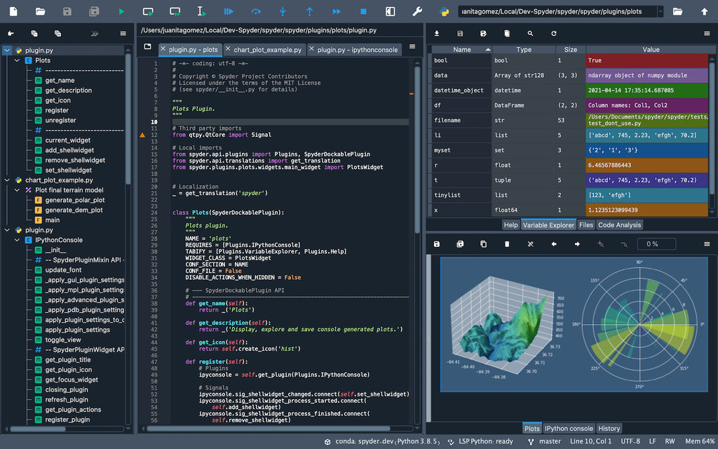

**Spyder:** editor, variable explorer, plots and console in one window

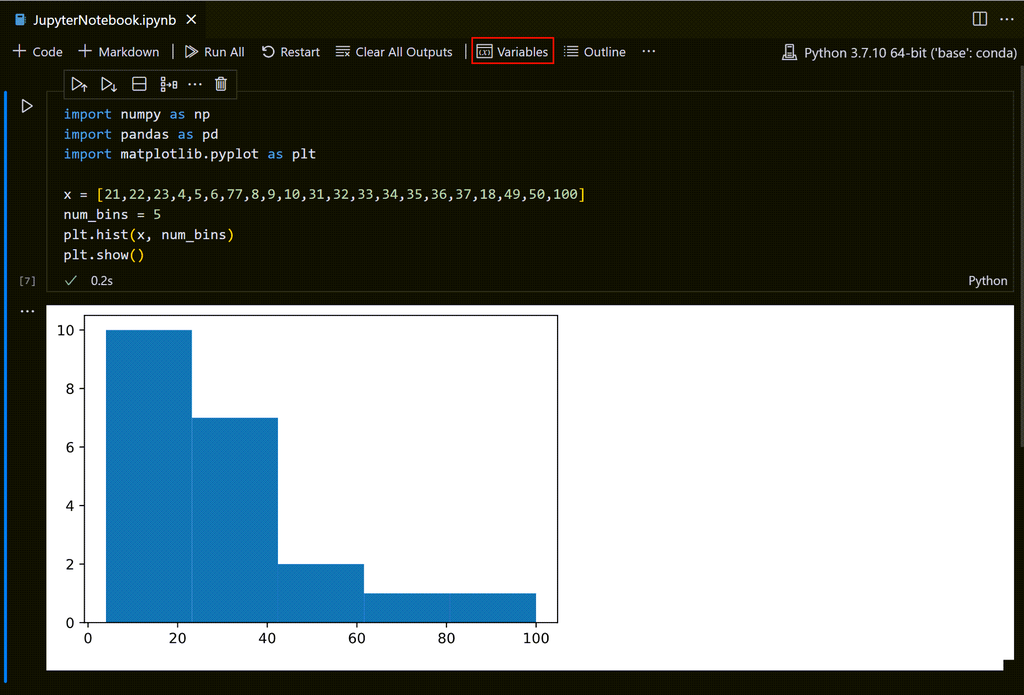

**VS Code:** a Jupyter notebook with its variable explorer

25

26

Notebooks: power and pitfalls

Rerunning GitHub notebooks

% of Python notebooks with a clear cell order

Attempted

100

Ran without errors

24.1

**Gave the same results**

**4.0**

36% had cells run out of order; 29% of failures were missing modules

Pimentel et al. (2019), MSR · 1.16 million unique notebooks

Before you share: always restart the kernel and run all.

jupytext

Pairs each .ipynb with a .py that diffs cleanly in git

marimo

Reactive: dependent cells rerun; saved as plain .py

Quarto

Text-first documents that execute code, like this course site

Packages and environments

Getting the same versions of everything, on every machine, next year too

Why environments exist

One global Python

Thesis project pins numpy 1.26

This course needs numpy 2.x

**Result:** installing one silently breaks the other

→

One environment per project

**thesis:** numpy 1.26, frozen for the paper

**hwrs564a:** numpy 2.x, flopy, mf6

**Result:** each rebuilt from one file

A computational environment is the operating system, installed software, package versions, configuration and hardware your result depends on.

The Turing Way, “Reproducible Environments” (CC BY 4.0) · see also [xkcd 1987, “Python Environment”](https://xkcd.com/1987/)

28

Package managers compared

Tool

Installs from

Binary stuff (GDAL, HDF5, mf6)?

Lockfile

pip + venv

PyPI

Only what wheels bundle

pylock.toml (PEP 751)

conda, mamba

conda-forge

Yes

via conda-lock

pixi

conda-forge + PyPI

Yes

pixi.lock

uv

PyPI

Only what wheels bundle

uv.lock

Poetry

PyPI

Only what wheels bundle

poetry.lock

For hydrology, conda-forge matters: GDAL, HDF5, netCDF and the mf6 executable are compiled libraries, not pure Python.

Speed is the new frontier: uv claims 10–100× faster than pip; pixi over 10× faster than conda (their own benchmarks).

29

An example environment

# environment.yml

name: hwrs564a

channels:

- conda-forge

dependencies:

- python=3.12

- numpy

- pandas

- xarray

- dask

- matplotlib

- jupyterlab

- netcdf4

- geopandas

- rioxarray

- flopy

- modflow6 # mf6

conda (Miniforge)

conda env create -f environment.yml

conda activate hwrs564a

pixi

pixi init --import environment.yml

pixi run jupyter lab

uv (PyPI only, so fetch mf6 with FloPy)

uv init hwrs564a && cd hwrs564a

uv add flopy xarray dask netcdf4 jupyterlab

uv run get-modflow :python

30

A comparison of common tasks

Job

pip + venv

conda

pixi

uv

Create

python -m venv .venv

conda create -n hwrs564a python=3.12

pixi init

uv init

Activate

source .venv/bin/activate

conda activate hwrs564a

pixi shell # optional

# not needed, but can use pip+venv solution

Add a package

pip install flopy

conda install flopy

pixi add flopy

uv add flopy

Record versions

pip freeze > requirements.txt

conda env export --from-history > environment.yml

# pixi.lock, automatic

# uv.lock, automatic

Rebuild elsewhere

pip install -r requirements.txt

conda env create -f environment.yml

pixi install

uv sync

Run a script

python model.py

conda run -n hwrs564a python model.py

pixi run python model.py

uv run model.py

activate shown for macOS/Linux; Windows uses .venv\Scripts\activate

31

When to reach for uv

A pure-Python project

uv init

uv add xarray dataretrieval

uv sync

Commit pyproject.toml and uv.lock; uv sync rebuilds it exactly

One analysis script

uv add --script gauges.py dataretrieval

uv run gauges.py

Dependencies live in the script’s header (PEP 723); uv builds a throwaway env

A specific Python

uv python install 3.12

uv venv --python 3.12

uv downloads Python itself: no system Python or pyenv needed

Speeding up pip

uv pip install -r requirements.txt

Same pip commands and files, much faster: good for older repos

One-off tools

uvx jupytext --to py lab.ipynb

Runs a tool in its own temporary env without touching yours

When not to use uv

Compiled tools and C libraries (e.g. GDAL command line)

32

How environments and kernels connect

Front end

JupyterLab or VS Code: shows the notebook, runs none of your code

Kernel spec

kernel.json: a name plus the path to one environment’s python

hwrs564a · selected kernel

numpy 2.x, flopy, mf6, ipykernel

thesis · another kernel

numpy 1.26, ipykernel

base

jupyterlab: the front end itself

**Kernel process:** hwrs564a’s python runs each cell and sends the results back

1 · Create the env

with conda, pixi, uv or venv

→

2 · Add ipykernel

into that same environment

→

3 · Register it

python -m ipykernel install --user --name hwrs564a

→

4 · Pick the kernel

JupyterLab’s kernel menu or VS Code’s kernel picker

ModuleNotFoundError in a notebook? Check the kernel before you reinstall.

33

Channels, lockfiles, containers

Channels

Use conda-forge through Miniforge: community-run, over 1 billion downloads a month by 2025.

Anaconda’s *defaults* channel has its own terms; university teaching and research are free, but conda-forge sidesteps the question.

Lockfiles

environment.yml says what you asked for. A lockfile records exactly what you got, for every platform.

pixi.lock, uv.lock, conda-lock, and Python’s new pylock.toml standard .

Containers

Docker packages the operating system layer too.

On UA HPC, use Apptainer (formerly Singularity), which can build from a Docker image. Binder builds a session from environment.yml.

Reproducibility is layered: environment file, then lockfile, then container. Go as far as your result needs.

34

Containers: the machine in a file

Dockerfile

The recipe: a base OS plus your environment

→

Image

Built once, in layers, with a version tag

→

Registry

GitHub Container Registry or Docker Hub

→

Container

A running copy: laptop, HPC, cloud, Codespaces

# Dockerfile: the course environment on a small Linux base

FROM mambaorg/micromamba

COPY --chown=$MAMBA_USER:$MAMBA_USER environment.yml /tmp/environment.yml

RUN micromamba install -y -n base -f /tmp/environment.yml && micromamba clean --all --yes

Environment vs container

An environment pins packages. A container also pins the operating system, system libraries and tools like mf6.

On UA HPC: Apptainer

apptainer build hw.sif docker://ghcr.io/OWNER/hwrs564a

apptainer exec hw.sif python model.py

35

36

Where the compute lives

Option

Good for

Cost

Software via

Your laptop

Writing code, small models

Yours

conda, pixi or uv

UA HPC (Puma, Ocelote)

Big runs, many jobs, GPUs

Free standard allocation

Slurm, modules, Apptainer

National HPC (DOE, NCAR)

Continental-scale and climate runs

Free, by allocation proposal

Modules, containers

Hosted JupyterHub

Teaching; notebooks near data

Free or institutional

Preinstalled kernels

AWS, Google Cloud, Azure

Cloud-hosted data, bursts

Pay per hour

Containers, dask

GitHub Codespaces

A ready-to-code repo

Free monthly quota

Dev container

Move the computer to the data: NOAA and NASA publish petabytes on commercial clouds, including remote sensing datasets (MODIS, LandSat, etc), and forecasting/climate simulations (GEFS, CMIP6, etc).

How GitHub Codespaces works

1 · Repo

Your code plus .devcontainer/ devcontainer.json

→

2 · Build

GitHub builds that container on a cloud VM, 2 to 32 cores

→

3 · Codespace

Your clone in /workspaces; files persist between sessions

→

4 · Connect

VS Code in the browser or on your desktop, or JupyterLab

Stops

After 30 minutes idle (adjustable), and after 12 hours at most

Deleted

After 30 days stopped, unless you change the retention period

Free quota

120 core-hours and 15 GB a month; Pro: 180 and 20 GB

37

A dev container for this course

The repo

hwrs564a/

├── .devcontainer/

│ └── devcontainer.json

├── Dockerfile

├── environment.yml

└── notebooks/

The same environment.yml drives your laptop, the container, Binder and Codespaces.

.devcontainer/devcontainer.json

{

"name": "hwrs564a",

"build": {

"dockerfile": "../Dockerfile",

"context": ".."

},

"customizations": {

"vscode": {

"extensions": ["ms-python.python",

"ms-toolsai.jupyter"]

}

}

}

**Your turn:** on the course repo, Code → Codespaces → Create codespace on main, then run the MODFLOW test notebook.

38

Your setup, before next class

1. Install python,
2. Build the hwrs564a environment; check that import flopy and mf6 both work
3. Install VS Code with the Python and Jupyter extensions, or the the editor of your choice
4. Clone the course material to your local machine and ensure you can run the labs

Questions?

39